# Korean Drama Analysis

Fall 2024

Author

Nhi Luong and James Le

Published

September 22, 2026

## Context and Background

South Korea’s movies and TV series have played a crucial role in her intensive culture export efforts to boost the nation’s ability to “shape the preferences of others [country] through attraction of values, policies, and culture as distinct from coercion by economic and/or military means” (i.e. soft power) [^1]. Its influence in the US specifically is undeniable as many Korean cultural products have become a part of the collective mainstream cultural landscape from Kpop music groups like BTS and Black Pink to the critically and commercially acclaimed show: Squid Game. The story of Squid Game focuses on the anxiety and hopelessness of the lower class and neglected groups, whose only option to escape poverty or paying gambling debt is to participate in life-staking children’s games for the entertainment of the ultra-wealthy.

Dive into the same mindset of capitalist horror is the film Parasite which is the first foreign film to win best picture from the Oscar and has been considered a historical step for the Korean media landscape, breaking the old US exclusive-winning convention of this category. These media provide a medium for many during and after the pandemics where the same sentiments of the public resonate with the message of these shows. How do South Korean shows make such an impact? What can we learn from one of the Four Asian Tigers [^2] cultural production and publishing’s history and journey? In this project, we want to explore “Which original network has the highest number of Korean drama series on weekdays and weekends, and how does it compare to other days of the week?” and “Which original network has the highest variation in IMDb ratings, and how does it compare to others in terms of the median rating?” .

### IMDb Ratings Across Original Networks

But how popular is the Korean Wave with its cultural products of television that have taken the world by storm and especially in the West? We would like to touch the surface of the Kdrama popularity through the IMDb rating of these shows while comparing them between networks to assess such impact. Here, we define original network of a show as a broadcasting channel that invests in the show and airs it first.

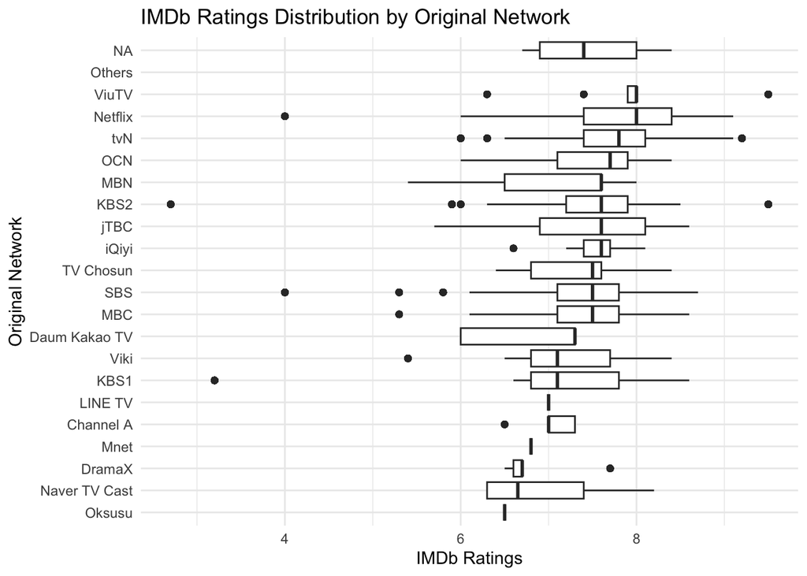

**Observation**

### Aired Day of K-drama Series

One way to examine the strategy to their success would be through the classic strategy of TV networks in their choice of aired day to be competitive with other networks. We will visualized that concept through the top 10 original networks below.

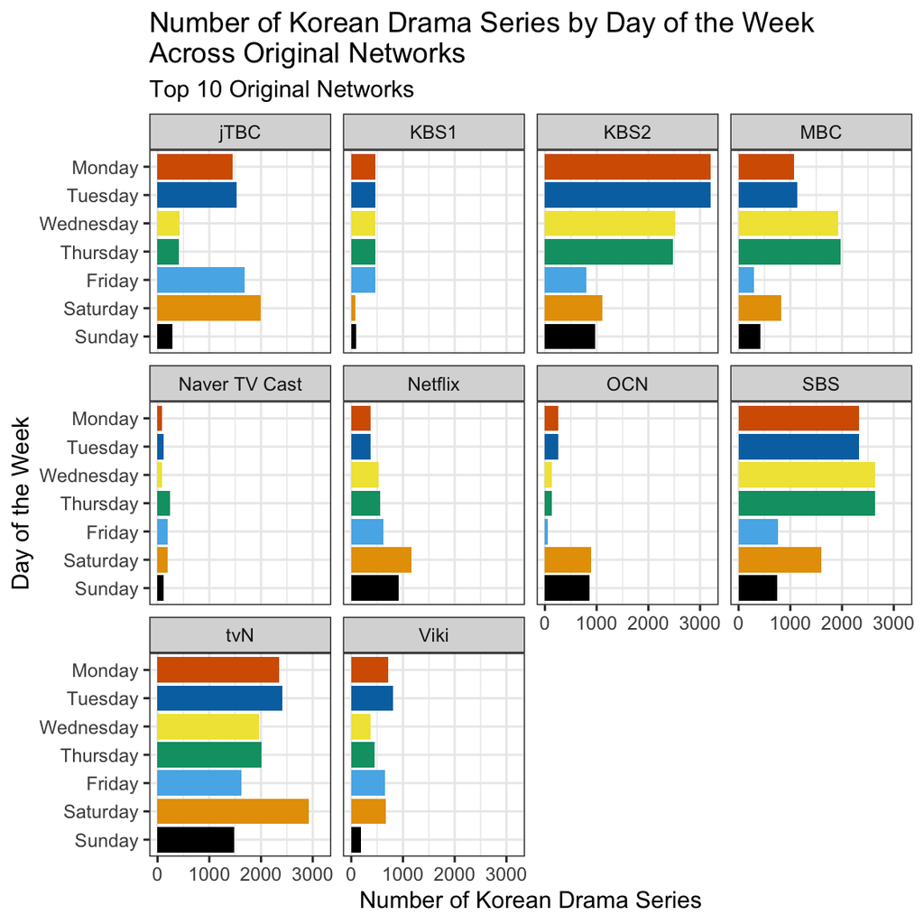

Figure 2: Number of Korean Drama Series by Days of the Week Across Top 10 Original Networks. This chart shows that KBS2, SBS, and tvN aired the highest number of Korean drama series, with peaks on Monday, Tuesday, Wednesday, Thursday, and Saturday. Data were collected from the publicly available website mydramalist.com, where users contribute information about Asian TV shows and movies. The dataset includes 810 distinct shows spanning from 2002 to 2022. No statistical tests were performed.

**Observation**

- This graph illustrates that Tuesday and Wednesday are the most popular days for airing dramas across multiple networks. Conversely, Sundays and Fridays show relatively lower activity in terms of drama releases, indicating a preference for mid-week broadcasting. One possible explanation for these trends due to market demands. Sunday is the final weekend day which leads to lower viewership while the reason Friday has less demand might be due to overtime working/studying schedule or the population at large going out and not staying at home watching TV. Another notable observation would be that the top four networks dominated the market where KBS, MBC and SBS are public television networks and tvN is a private one. Each network also have their own airing strategies as tvN aired the most shows on Saturday, KBS on Monday and Tuesday while MBC have the highest proportion on Wednesday and Thursday. We can also observed that investment in the public sector (KBS, SBS) is as important as the private sector (tvN) for the television industry as the government heavily subsided the industry through investment in film education from the Korean Film Academy, interest-free or low-interest loans for enterprise [^3] and tax policies[^4] that encourage local business to invest in film production beside their own direct investment to the industry [^5].

### K-drama on Netflix Before and After Covid

On March 11, 2020, WHO declared COVID-19 outbreak a global pandemic [^6] that continued to last for the next 3 years. Following the announcement was a string of global and national shutdowns. Because of that, more people spent more time inside watching shows on Netflix and got to learn more about Korean drama. In this section, we would like to look at Korean drama series on Netflix to identify changes in the number of drama series as well as the most popular genres among the series before and after the Covid pandemic. We have decided to use “2020” as a mark for before and after Covid pandemic instead of “March 2020” for simplicity.

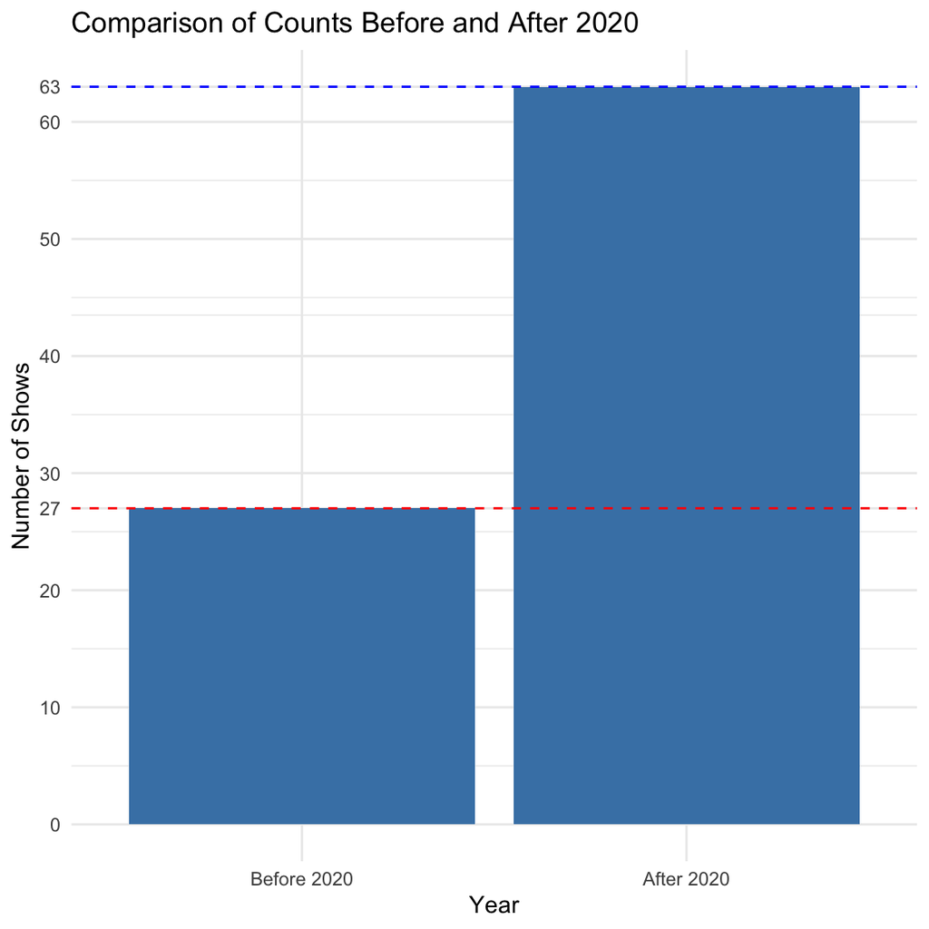

Figure 3: The number of Korean drama series on Netflix after 2020 is two times greater than the number of Korean shows on Netflix before 2020. The data were collected from mydramalist.com and include IMDb ratings for 810 dramas spanning from 2002 to 2022. The years were grouped into two categorical groups for comparison. No statistical tests were performed.

- We briefly look at the number of Korean drama shows on Netflix before 2020 and after 2020 and see that after the announcement of the COVID-19 a global pandemic up until 2022, Netflix has added 36 more Korean drama shows into their collection, showing Netflix’s interest in investing into Korean shows in these recent years. Naturally, our next question would be “Then does Netflix have a preference of Korean drama shows’ genres that they want to add that can attract more viewers?” We look at this question in the following graph.

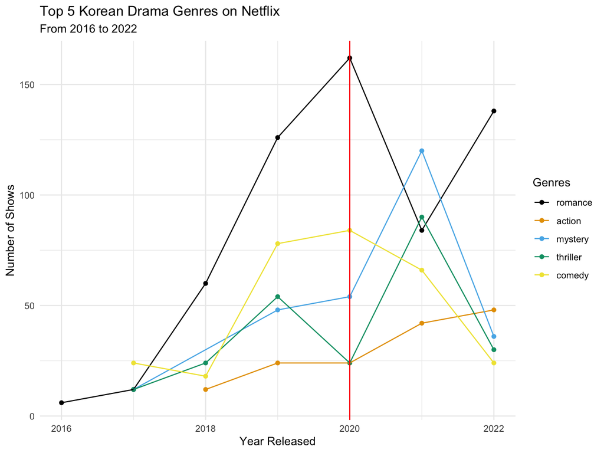

## Conclusion

Through the project, we have looked at IMDb ratings of Korean shows by original networks, their air day in the week, and changes of Korean shows on Netflix. We see that overall, the Korean drama industry is investing a lot into their shows so that the shows can be known more globally. As a result of their strategy and popularity of Korean drama, these shows receive more investment from Netflix and appear on the streaming service more, which makes a big profit for Netflix while as the same time receive worldwide popularity. We believe that Korean drama shows will continue to thrive even more in the future.

## Footnotes

[^1]: Marklund, Carl. “Soft Power.” International Encyclopedia of Human Geography, edited by Audrey Kobayashi, 2nd ed., Elsevier Science & Technology, 2020. Credo Reference, https://search.credoreference.com/articles/Qm9va0FydGljbGU6NTkwMDQ=?aid=79650.
[^2]: Day, D.-C. “Four Asian Tigers’ Political and Economic Development Revisited 1998-2017: From the Perspective of National Identity”. Asian Journal of Interdisciplinary Research, vol. 4, no. 4, Dec. 2021, pp. 54-61, doi:10.54392/ajir2147.
[^3]: Kang, Jennifer M. “Better than Television: The Rise of Korean Web Dramas.” International Journal of Cultural Studies, vol. 24, no. 6, May 2021, p. 136787792110145, https://doi.org/10.1177/13678779211014532.
[^4]: PricewaterhouseCoopers International Limited. “Korea, Republic of - Corporate - Tax Credits and Incentives.” Pwc.com, 2024, taxsummaries.pwc.com/republic-of-korea/corporate/tax-credits-and-incentives. Accessed 12 Dec. 2024.
[^5]: Shim, Doobo. “Whiter the Korean Flim Industry?” Acta Koreana, vol. 14, no. 1, June 2011, pp. 213–27, https://doi.org/10.18399/acta.2011.14.1.010. Accessed 1 Apr. 2020.
[^6]: Cucinotta, Domenico, and Maurizio Vanelli. “WHO Declares COVID-19 a Pandemic.” Acta Bio Medica: Atenei Parmensis, vol. 91, no. 1, 2020, pp. 157–60. PubMed Central, https://doi.org/10.23750/abm.v91i1.9397.